# Risk Factor Analysis

## Outcome Variable

**Outcome Variable:** sstunted

## Predictor Variables

**Intervention Variable:** perdiar6

**Adjustment Set:**

- arm
- sex
- W_mage
- meducyrs
- feducyrs
- hhwealth_quart
- hfoodsec
- W_mhtcm
- W_mwtkg
- W_mbmi
- W_birthwt
- W_birthlen
- W_nrooms
- month
- brthmon
- impfloor
- impsan
- safeh20
- delta_W_mage
- delta_meducyrs
- delta_feducyrs
- delta_hhwealth_quart
- delta_hfoodsec
- delta_W_mhtcm
- delta_W_mwtkg
- delta_W_mbmi
- delta_W_birthwt
- delta_W_birthlen
- delta_W_nrooms
- delta_month
- delta_brthmon
- delta_impfloor
- delta_impsan
- delta_safeh20

## Stratifying Variables

The analysis was stratified on these variable(s):

- agecat
- studyid
- country

## Data Summary

| agecat | studyid | country | perdiar6 | sstunted | n_cell | n |
| --- | --- | --- | --- | --- | --- | --- |
| Birth | ki0047075b-MAL-ED | BANGLADESH | 0% | 0 | 69 | 231 |
| Birth | ki0047075b-MAL-ED | BANGLADESH | 0% | 1 | 3 | 231 |
| Birth | ki0047075b-MAL-ED | BANGLADESH | (0%, 5%] | 0 | 87 | 231 |
| Birth | ki0047075b-MAL-ED | BANGLADESH | (0%, 5%] | 1 | 3 | 231 |
| Birth | ki0047075b-MAL-ED | BANGLADESH | >5% | 0 | 66 | 231 |
| Birth | ki0047075b-MAL-ED | BANGLADESH | >5% | 1 | 3 | 231 |
| Birth | ki0047075b-MAL-ED | BRAZIL | 0% | 0 | 54 | 65 |
| Birth | ki0047075b-MAL-ED | BRAZIL | 0% | 1 | 3 | 65 |
| Birth | ki0047075b-MAL-ED | BRAZIL | (0%, 5%] | 0 | 6 | 65 |
| Birth | ki0047075b-MAL-ED | BRAZIL | (0%, 5%] | 1 | 0 | 65 |
| Birth | ki0047075b-MAL-ED | BRAZIL | >5% | 0 | 2 | 65 |
| Birth | ki0047075b-MAL-ED | BRAZIL | >5% | 1 | 0 | 65 |
| Birth | ki0047075b-MAL-ED | INDIA | 0% | 0 | 11 | 47 |
| Birth | ki0047075b-MAL-ED | INDIA | 0% | 1 | 1 | 47 |
| Birth | ki0047075b-MAL-ED | INDIA | (0%, 5%] | 0 | 23 | 47 |
| Birth | ki0047075b-MAL-ED | INDIA | (0%, 5%] | 1 | 1 | 47 |
| Birth | ki0047075b-MAL-ED | INDIA | >5% | 0 | 11 | 47 |
| Birth | ki0047075b-MAL-ED | INDIA | >5% | 1 | 0 | 47 |
| Birth | ki0047075b-MAL-ED | NEPAL | 0% | 0 | 8 | 27 |
| Birth | ki0047075b-MAL-ED | NEPAL | 0% | 1 | 0 | 27 |
| Birth | ki0047075b-MAL-ED | NEPAL | (0%, 5%] | 0 | 10 | 27 |
| Birth | ki0047075b-MAL-ED | NEPAL | (0%, 5%] | 1 | 0 | 27 |
| Birth | ki0047075b-MAL-ED | NEPAL | >5% | 0 | 8 | 27 |
| Birth | ki0047075b-MAL-ED | NEPAL | >5% | 1 | 1 | 27 |
| Birth | ki0047075b-MAL-ED | PERU | 0% | 0 | 66 | 233 |
| Birth | ki0047075b-MAL-ED | PERU | 0% | 1 | 1 | 233 |
| Birth | ki0047075b-MAL-ED | PERU | (0%, 5%] | 0 | 70 | 233 |
| Birth | ki0047075b-MAL-ED | PERU | (0%, 5%] | 1 | 2 | 233 |
| Birth | ki0047075b-MAL-ED | PERU | >5% | 0 | 93 | 233 |
| Birth | ki0047075b-MAL-ED | PERU | >5% | 1 | 1 | 233 |

[output cut: 204 more lines]

The following strata were considered:

- agecat: 24 months, studyid: ki0047075b-MAL-ED, country: BANGLADESH
- agecat: 24 months, studyid: ki0047075b-MAL-ED, country: BRAZIL
- agecat: 24 months, studyid: ki0047075b-MAL-ED, country: INDIA
- agecat: 24 months, studyid: ki0047075b-MAL-ED, country: NEPAL
- agecat: 24 months, studyid: ki0047075b-MAL-ED, country: PERU
- agecat: 24 months, studyid: ki0047075b-MAL-ED, country: SOUTH AFRICA
- agecat: 24 months, studyid: ki0047075b-MAL-ED, country: TANZANIA, UNITED REPUBLIC OF
- agecat: 24 months, studyid: ki1000109-EE, country: PAKISTAN
- agecat: 24 months, studyid: ki1017093-NIH-Birth, country: BANGLADESH
- agecat: 24 months, studyid: ki1017093b-PROVIDE, country: BANGLADESH
- agecat: 24 months, studyid: ki1017093c-NIH-Crypto, country: BANGLADESH
- agecat: 24 months, studyid: ki1114097-CMIN, country: BANGLADESH
- agecat: 24 months, studyid: ki1114097-CONTENT, country: PERU
- agecat: 6 months, studyid: ki0047075b-MAL-ED, country: BANGLADESH
- agecat: 6 months, studyid: ki0047075b-MAL-ED, country: BRAZIL
- agecat: 6 months, studyid: ki0047075b-MAL-ED, country: INDIA
- agecat: 6 months, studyid: ki0047075b-MAL-ED, country: NEPAL
- agecat: 6 months, studyid: ki0047075b-MAL-ED, country: PERU
- agecat: 6 months, studyid: ki0047075b-MAL-ED, country: SOUTH AFRICA
- agecat: 6 months, studyid: ki0047075b-MAL-ED, country: TANZANIA, UNITED REPUBLIC OF
- agecat: 6 months, studyid: ki1000109-EE, country: PAKISTAN
- agecat: 6 months, studyid: ki1017093-NIH-Birth, country: BANGLADESH
- agecat: 6 months, studyid: ki1017093b-PROVIDE, country: BANGLADESH
- agecat: 6 months, studyid: ki1017093c-NIH-Crypto, country: BANGLADESH
- agecat: 6 months, studyid: ki1114097-CMIN, country: BANGLADESH
- agecat: 6 months, studyid: ki1114097-CONTENT, country: PERU
- agecat: Birth, studyid: ki0047075b-MAL-ED, country: BANGLADESH
- agecat: Birth, studyid: ki0047075b-MAL-ED, country: BRAZIL
- agecat: Birth, studyid: ki0047075b-MAL-ED, country: INDIA
- agecat: Birth, studyid: ki0047075b-MAL-ED, country: NEPAL
- agecat: Birth, studyid: ki0047075b-MAL-ED, country: PERU
- agecat: Birth, studyid: ki0047075b-MAL-ED, country: SOUTH AFRICA
- agecat: Birth, studyid: ki0047075b-MAL-ED, country: TANZANIA, UNITED REPUBLIC OF
- agecat: Birth, studyid: ki1000109-EE, country: PAKISTAN
- agecat: Birth, studyid: ki1017093-NIH-Birth, country: BANGLADESH
- agecat: Birth, studyid: ki1017093b-PROVIDE, country: BANGLADESH
- agecat: Birth, studyid: ki1017093c-NIH-Crypto, country: BANGLADESH
- agecat: Birth, studyid: ki1114097-CMIN, country: BANGLADESH
- agecat: Birth, studyid: ki1114097-CONTENT, country: PERU

### Dropped Strata

Some strata were dropped due to rare outcomes:

- agecat: Birth, studyid: ki0047075b-MAL-ED, country: BANGLADESH
- agecat: Birth, studyid: ki0047075b-MAL-ED, country: BRAZIL
- agecat: Birth, studyid: ki0047075b-MAL-ED, country: INDIA
- agecat: Birth, studyid: ki0047075b-MAL-ED, country: NEPAL
- agecat: Birth, studyid: ki0047075b-MAL-ED, country: PERU
- agecat: Birth, studyid: ki0047075b-MAL-ED, country: SOUTH AFRICA
- agecat: Birth, studyid: ki0047075b-MAL-ED, country: TANZANIA, UNITED REPUBLIC OF
- agecat: Birth, studyid: ki1000109-EE, country: PAKISTAN
- agecat: Birth, studyid: ki1017093-NIH-Birth, country: BANGLADESH
- agecat: Birth, studyid: ki1017093b-PROVIDE, country: BANGLADESH
- agecat: Birth, studyid: ki1017093c-NIH-Crypto, country: BANGLADESH
- agecat: Birth, studyid: ki1114097-CMIN, country: BANGLADESH
- agecat: Birth, studyid: ki1114097-CONTENT, country: PERU
- agecat: 6 months, studyid: ki0047075b-MAL-ED, country: BANGLADESH
- agecat: 6 months, studyid: ki0047075b-MAL-ED, country: BRAZIL
- agecat: 6 months, studyid: ki0047075b-MAL-ED, country: INDIA
- agecat: 6 months, studyid: ki0047075b-MAL-ED, country: NEPAL
- agecat: 6 months, studyid: ki0047075b-MAL-ED, country: PERU
- agecat: 6 months, studyid: ki0047075b-MAL-ED, country: SOUTH AFRICA
- agecat: 6 months, studyid: ki0047075b-MAL-ED, country: TANZANIA, UNITED REPUBLIC OF
- agecat: 6 months, studyid: ki1000109-EE, country: PAKISTAN
- agecat: 6 months, studyid: ki1017093b-PROVIDE, country: BANGLADESH
- agecat: 6 months, studyid: ki1114097-CONTENT, country: PERU
- agecat: 24 months, studyid: ki0047075b-MAL-ED, country: BRAZIL
- agecat: 24 months, studyid: ki0047075b-MAL-ED, country: NEPAL
- agecat: 24 months, studyid: ki0047075b-MAL-ED, country: PERU
- agecat: 24 months, studyid: ki0047075b-MAL-ED, country: SOUTH AFRICA
- agecat: 24 months, studyid: ki1000109-EE, country: PAKISTAN
- agecat: 24 months, studyid: ki1114097-CONTENT, country: PERU

## Methods Detail

We’re interested in the causal parameters $E[Y_a]$ for all values of $a \in \mathcal{A}$. These parameters represent the mean outcome if, possibly contrary to fact, we intervened to set all units to have $A=a$. Under the randomization and positivity assumptions, these are identified by the statistical parameters $\psi_a=E_W[E_{Y|A,W}(Y|A=a,W)]$. In addition, we’re interested in the mean of $Y$, $E[Y]$ under no intervention (the observed mean). We will estimate these parameters by using SuperLearner to fit the relevant likelihood factors – $E_{Y|A,W}(Y|A=a,W)$ and $p(A=a|W)$, and then updating our likelihood fit using a joint TMLE.

For unadjusted analyses ($W=\{\}$), initial likelihoods were estimated using Lrnr_glm to estimate the simple $E(Y|A)$ and Lrnr_mean to estimate $p(A)$. For adjusted analyses, a small library containing Lrnr_glmnet, Lrnr_xgboost, and Lrnr_mean was used.

Having estimated these parameters, we will then use the delta method to estimate relative risks and attributable risks relative to a prespecified baseline level of $A$.

# Results Detail

## Results Plots

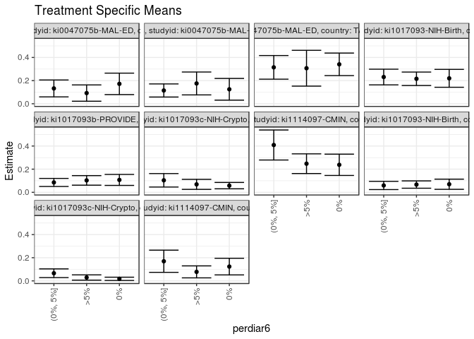

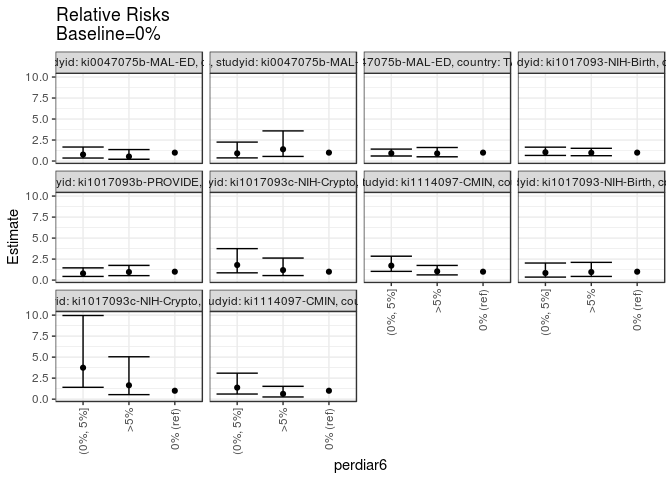

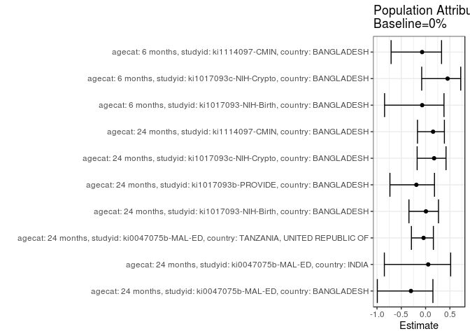

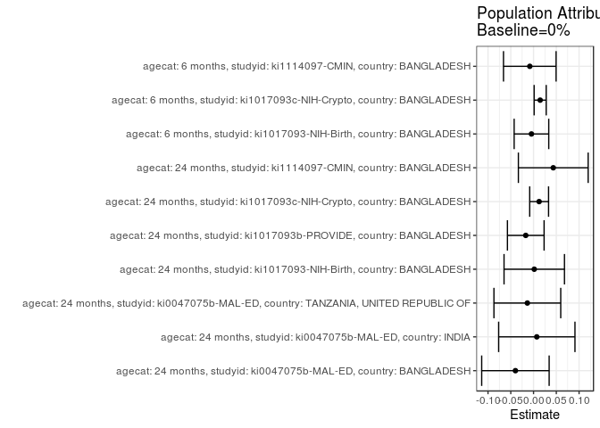

## Results Table

### Parameter: TSM

| agecat | studyid | country | intervention_level | baseline_level | estimate | ci_lower | ci_upper |
| --- | --- | --- | --- | --- | --- | --- | --- |
| 6 months | ki1017093-NIH-Birth | BANGLADESH | 0% | NA | 0.0697674 | 0.0257647 | 0.1137702 |
| 6 months | ki1017093-NIH-Birth | BANGLADESH | (0%, 5%] | NA | 0.0591716 | 0.0235657 | 0.0947774 |
| 6 months | ki1017093-NIH-Birth | BANGLADESH | >5% | NA | 0.0669456 | 0.0352303 | 0.0986609 |
| 6 months | ki1017093c-NIH-Crypto | BANGLADESH | 0% | NA | 0.0175953 | 0.0036310 | 0.0315596 |
| 6 months | ki1017093c-NIH-Crypto | BANGLADESH | (0%, 5%] | NA | 0.0658683 | 0.0282208 | 0.1035157 |
| 6 months | ki1017093c-NIH-Crypto | BANGLADESH | >5% | NA | 0.0289855 | 0.0061153 | 0.0518557 |
| 6 months | ki1114097-CMIN | BANGLADESH | 0% | NA | 0.1234568 | 0.0516699 | 0.1952437 |
| 6 months | ki1114097-CMIN | BANGLADESH | (0%, 5%] | NA | 0.1694915 | 0.0735595 | 0.2654235 |
| 6 months | ki1114097-CMIN | BANGLADESH | >5% | NA | 0.0776699 | 0.0258741 | 0.1294657 |
| 24 months | ki0047075b-MAL-ED | BANGLADESH | 0% | NA | 0.1718750 | 0.0792263 | 0.2645237 |
| 24 months | ki0047075b-MAL-ED | BANGLADESH | (0%, 5%] | NA | 0.1325301 | 0.0594128 | 0.2056474 |
| 24 months | ki0047075b-MAL-ED | BANGLADESH | >5% | NA | 0.0923077 | 0.0217724 | 0.1628430 |
| 24 months | ki0047075b-MAL-ED | INDIA | 0% | NA | 0.1250000 | 0.0312340 | 0.2187660 |
| 24 months | ki0047075b-MAL-ED | INDIA | (0%, 5%] | NA | 0.1147541 | 0.0580724 | 0.1714358 |
| 24 months | ki0047075b-MAL-ED | INDIA | >5% | NA | 0.1754386 | 0.0764823 | 0.2743949 |
| 24 months | ki0047075b-MAL-ED | TANZANIA, UNITED REPUBLIC OF | 0% | NA | 0.3407244 | 0.2433310 | 0.4381178 |
| 24 months | ki0047075b-MAL-ED | TANZANIA, UNITED REPUBLIC OF | (0%, 5%] | NA | 0.3147208 | 0.2125774 | 0.4168642 |
| 24 months | ki0047075b-MAL-ED | TANZANIA, UNITED REPUBLIC OF | >5% | NA | 0.3071655 | 0.1524302 | 0.4619009 |
| 24 months | ki1017093-NIH-Birth | BANGLADESH | 0% | NA | 0.2198720 | 0.1425320 | 0.2972120 |
| 24 months | ki1017093-NIH-Birth | BANGLADESH | (0%, 5%] | NA | 0.2310508 | 0.1633369 | 0.2987646 |
| 24 months | ki1017093-NIH-Birth | BANGLADESH | >5% | NA | 0.2157556 | 0.1577319 | 0.2737794 |
| 24 months | ki1017093b-PROVIDE | BANGLADESH | 0% | NA | 0.1070725 | 0.0596072 | 0.1545378 |
| 24 months | ki1017093b-PROVIDE | BANGLADESH | (0%, 5%] | NA | 0.0852402 | 0.0503703 | 0.1201100 |
| 24 months | ki1017093b-PROVIDE | BANGLADESH | >5% | NA | 0.1029495 | 0.0616051 | 0.1442940 |
| 24 months | ki1017093c-NIH-Crypto | BANGLADESH | 0% | NA | 0.0577617 | 0.0302618 | 0.0852617 |
| 24 months | ki1017093c-NIH-Crypto | BANGLADESH | (0%, 5%] | NA | 0.1037736 | 0.0456610 | 0.1618862 |
| 24 months | ki1017093c-NIH-Crypto | BANGLADESH | >5% | NA | 0.0687023 | 0.0253447 | 0.1120599 |
| 24 months | ki1114097-CMIN | BANGLADESH | 0% | NA | 0.2376745 | 0.1455158 | 0.3298333 |
| 24 months | ki1114097-CMIN | BANGLADESH | (0%, 5%] | NA | 0.4088599 | 0.2791751 | 0.5385447 |
| 24 months | ki1114097-CMIN | BANGLADESH | >5% | NA | 0.2473001 | 0.1621622 | 0.3324379 |

### Parameter: E(Y)

| agecat | studyid | country | intervention_level | baseline_level | estimate | ci_lower | ci_upper |
| --- | --- | --- | --- | --- | --- | --- | --- |
| 6 months | ki1017093-NIH-Birth | BANGLADESH | NA | NA | 0.0651769 | 0.0442802 | 0.0860736 |
| 6 months | ki1017093c-NIH-Crypto | BANGLADESH | NA | NA | 0.0321678 | 0.0192256 | 0.0451101 |
| 6 months | ki1114097-CMIN | BANGLADESH | NA | NA | 0.1152263 | 0.0749980 | 0.1554547 |
| 24 months | ki0047075b-MAL-ED | BANGLADESH | NA | NA | 0.1320755 | 0.0863920 | 0.1777589 |
| 24 months | ki0047075b-MAL-ED | INDIA | NA | NA | 0.1321586 | 0.0880054 | 0.1763117 |
| 24 months | ki0047075b-MAL-ED | TANZANIA, UNITED REPUBLIC OF | NA | NA | 0.3271028 | 0.2640978 | 0.3901078 |
| 24 months | ki1017093-NIH-Birth | BANGLADESH | NA | NA | 0.2214452 | 0.1821080 | 0.2607825 |
| 24 months | ki1017093b-PROVIDE | BANGLADESH | NA | NA | 0.0899654 | 0.0666186 | 0.1133122 |
| 24 months | ki1017093c-NIH-Crypto | BANGLADESH | NA | NA | 0.0700389 | 0.0479542 | 0.0921236 |
| 24 months | ki1114097-CMIN | BANGLADESH | NA | NA | 0.2809917 | 0.2242434 | 0.3377401 |

### Parameter: RR

| agecat | studyid | country | intervention_level | baseline_level | estimate | ci_lower | ci_upper |
| --- | --- | --- | --- | --- | --- | --- | --- |
| 6 months | ki1017093-NIH-Birth | BANGLADESH | 0% | 0% | 1.0000000 | 1.0000000 | 1.000000 |
| 6 months | ki1017093-NIH-Birth | BANGLADESH | (0%, 5%] | 0% | 0.8481262 | 0.3547163 | 2.027869 |
| 6 months | ki1017093-NIH-Birth | BANGLADESH | >5% | 0% | 0.9595537 | 0.4360054 | 2.111770 |
| 6 months | ki1017093c-NIH-Crypto | BANGLADESH | 0% | 0% | 1.0000000 | 1.0000000 | 1.000000 |
| 6 months | ki1017093c-NIH-Crypto | BANGLADESH | (0%, 5%] | 0% | 3.7435128 | 1.4077570 | 9.954764 |
| 6 months | ki1017093c-NIH-Crypto | BANGLADESH | >5% | 0% | 1.6473429 | 0.5379715 | 5.044391 |
| 6 months | ki1114097-CMIN | BANGLADESH | 0% | 0% | 1.0000000 | 1.0000000 | 1.000000 |
| 6 months | ki1114097-CMIN | BANGLADESH | (0%, 5%] | 0% | 1.3728814 | 0.6098466 | 3.090619 |
| 6 months | ki1114097-CMIN | BANGLADESH | >5% | 0% | 0.6291262 | 0.2597075 | 1.524022 |
| 24 months | ki0047075b-MAL-ED | BANGLADESH | 0% | 0% | 1.0000000 | 1.0000000 | 1.000000 |
| 24 months | ki0047075b-MAL-ED | BANGLADESH | (0%, 5%] | 0% | 0.7710843 | 0.3565481 | 1.667576 |
| 24 months | ki0047075b-MAL-ED | BANGLADESH | >5% | 0% | 0.5370630 | 0.2108158 | 1.368193 |
| 24 months | ki0047075b-MAL-ED | INDIA | 0% | 0% | 1.0000000 | 1.0000000 | 1.000000 |
| 24 months | ki0047075b-MAL-ED | INDIA | (0%, 5%] | 0% | 0.9180328 | 0.3739364 | 2.253817 |
| 24 months | ki0047075b-MAL-ED | INDIA | >5% | 0% | 1.4035088 | 0.5490542 | 3.587691 |
| 24 months | ki0047075b-MAL-ED | TANZANIA, UNITED REPUBLIC OF | 0% | 0% | 1.0000000 | 1.0000000 | 1.000000 |
| 24 months | ki0047075b-MAL-ED | TANZANIA, UNITED REPUBLIC OF | (0%, 5%] | 0% | 0.9236815 | 0.6005612 | 1.420650 |
| 24 months | ki0047075b-MAL-ED | TANZANIA, UNITED REPUBLIC OF | >5% | 0% | 0.9015073 | 0.5045577 | 1.610748 |
| 24 months | ki1017093-NIH-Birth | BANGLADESH | 0% | 0% | 1.0000000 | 1.0000000 | 1.000000 |
| 24 months | ki1017093-NIH-Birth | BANGLADESH | (0%, 5%] | 0% | 1.0508422 | 0.6688006 | 1.651119 |
| 24 months | ki1017093-NIH-Birth | BANGLADESH | >5% | 0% | 0.9812784 | 0.6342881 | 1.518091 |
| 24 months | ki1017093b-PROVIDE | BANGLADESH | 0% | 0% | 1.0000000 | 1.0000000 | 1.000000 |
| 24 months | ki1017093b-PROVIDE | BANGLADESH | (0%, 5%] | 0% | 0.7960975 | 0.4352197 | 1.456210 |
| 24 months | ki1017093b-PROVIDE | BANGLADESH | >5% | 0% | 0.9614933 | 0.5286626 | 1.748695 |
| 24 months | ki1017093c-NIH-Crypto | BANGLADESH | 0% | 0% | 1.0000000 | 1.0000000 | 1.000000 |
| 24 months | ki1017093c-NIH-Crypto | BANGLADESH | (0%, 5%] | 0% | 1.7965802 | 0.8614509 | 3.746818 |
| 24 months | ki1017093c-NIH-Crypto | BANGLADESH | >5% | 0% | 1.1894084 | 0.5395188 | 2.622137 |
| 24 months | ki1114097-CMIN | BANGLADESH | 0% | 0% | 1.0000000 | 1.0000000 | 1.000000 |
| 24 months | ki1114097-CMIN | BANGLADESH | (0%, 5%] | 0% | 1.7202513 | 1.0405227 | 2.844017 |
| 24 months | ki1114097-CMIN | BANGLADESH | >5% | 0% | 1.0404988 | 0.6197831 | 1.746801 |

### Parameter: PAR

| agecat | studyid | country | intervention_level | baseline_level | estimate | ci_lower | ci_upper |
| --- | --- | --- | --- | --- | --- | --- | --- |
| 6 months | ki1017093-NIH-Birth | BANGLADESH | 0% | NA | -0.0045905 | -0.0425728 | 0.0333917 |
| 6 months | ki1017093c-NIH-Crypto | BANGLADESH | 0% | NA | 0.0145725 | 0.0012871 | 0.0278579 |
| 6 months | ki1114097-CMIN | BANGLADESH | 0% | NA | -0.0082305 | -0.0659895 | 0.0495286 |
| 24 months | ki0047075b-MAL-ED | BANGLADESH | 0% | NA | -0.0397995 | -0.1138812 | 0.0342822 |
| 24 months | ki0047075b-MAL-ED | INDIA | 0% | NA | 0.0071586 | -0.0766467 | 0.0909639 |
| 24 months | ki0047075b-MAL-ED | TANZANIA, UNITED REPUBLIC OF | 0% | NA | -0.0136216 | -0.0869722 | 0.0597291 |
| 24 months | ki1017093-NIH-Birth | BANGLADESH | 0% | NA | 0.0015732 | -0.0647957 | 0.0679422 |
| 24 months | ki1017093b-PROVIDE | BANGLADESH | 0% | NA | -0.0171071 | -0.0573574 | 0.0231432 |
| 24 months | ki1017093c-NIH-Crypto | BANGLADESH | 0% | NA | 0.0122772 | -0.0084323 | 0.0329866 |
| 24 months | ki1114097-CMIN | BANGLADESH | 0% | NA | 0.0433172 | -0.0333073 | 0.1199417 |

### Parameter: PAF

| agecat | studyid | country | intervention_level | baseline_level | estimate | ci_lower | ci_upper |
| --- | --- | --- | --- | --- | --- | --- | --- |
| 6 months | ki1017093-NIH-Birth | BANGLADESH | 0% | NA | -0.0704319 | -0.8443502 | 0.3787381 |
| 6 months | ki1017093c-NIH-Crypto | BANGLADESH | 0% | NA | 0.4530154 | -0.0802446 | 0.7230330 |
| 6 months | ki1114097-CMIN | BANGLADESH | 0% | NA | -0.0714286 | -0.7098807 | 0.3286320 |
| 24 months | ki0047075b-MAL-ED | BANGLADESH | 0% | NA | -0.3013393 | -0.9935093 | 0.1505012 |
| 24 months | ki0047075b-MAL-ED | INDIA | 0% | NA | 0.0541667 | -0.8488415 | 0.5161290 |
| 24 months | ki0047075b-MAL-ED | TANZANIA, UNITED REPUBLIC OF | 0% | NA | -0.0416431 | -0.2918855 | 0.1601265 |
| 24 months | ki1017093-NIH-Birth | BANGLADESH | 0% | NA | 0.0071044 | -0.3427673 | 0.2658135 |
| 24 months | ki1017093b-PROVIDE | BANGLADESH | 0% | NA | -0.1901523 | -0.7338548 | 0.1830559 |
| 24 months | ki1017093c-NIH-Crypto | BANGLADESH | 0% | NA | 0.1752908 | -0.1738390 | 0.4205805 |
| 24 months | ki1114097-CMIN | BANGLADESH | 0% | NA | 0.1541583 | -0.1671181 | 0.3869959 |